# 💳 Credit Risk Prediction — Exploratory Data Analysis

## Step 12 — Skewness Analysis and Power Transformation

**Why:** Linear models assume approximately normal feature distributions. PowerTransformer reduces skewness and improves model coefficient stability.

**Business insight:** Applying transformation only to the scaled preprocessor is a key architectural decision — tree models (RF, XGB, LightGBM) are skew-invariant.

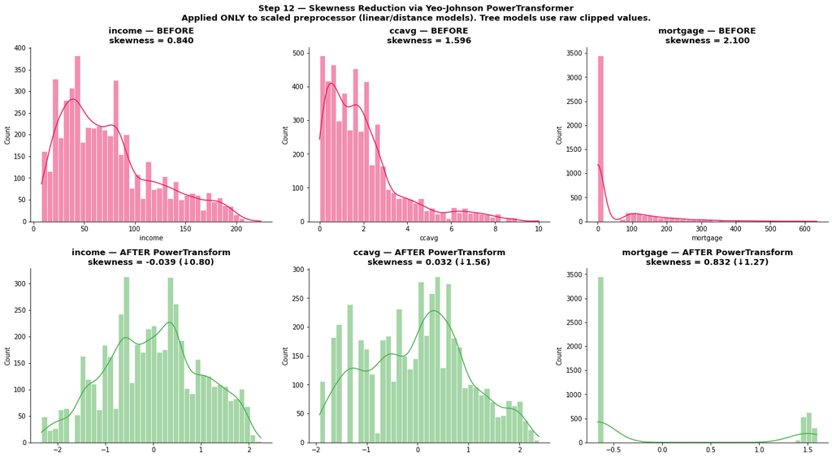

```python
from sklearn.preprocessing import PowerTransformer
skew_cols = ['income', 'ccavg', 'mortgage']
pt = PowerTransformer(method='yeo-johnson')
fig, axes = plt.subplots(2, 3, figsize=(18, 10))

for i, col in enumerate(skew_cols):
    raw = df[col].dropna().values.reshape(-1, 1)
    transformed = pt.fit_transform(raw).flatten()
    sk_before = df[col].skew(); sk_after = pd.Series(transformed).skew()
    improvement = abs(sk_before) - abs(sk_after)
    sns.histplot(df[col], kde=True, bins=40, ax=axes[0, i], color=PINK, edgecolor='white')
    axes[0, i].set_title(f'{col} — BEFORE\nskewness = {sk_before:.3f}', fontweight='bold')
    sns.histplot(transformed, kde=True, bins=40, ax=axes[1, i], color=GREEN, edgecolor='white')
    axes[1, i].set_title(f'{col} — AFTER PowerTransform\nskewness = {sk_after:.3f} (↓{improvement:.2f})', fontweight='bold')

plt.suptitle('Step 12 — Skewness Reduction via Yeo-Johnson PowerTransformer\n'
             'Applied ONLY to scaled preprocessor (linear/distance models). Tree models use raw clipped values.',
             fontsize=13, fontweight='bold')
plt.tight_layout(); plt.show()
```

**📌 Observation:** PowerTransformer dramatically reduces skewness in all three features — making them suitable for Logistic Regression, SVM, KNN.

**💡 Pipeline decision:** Dual preprocessor — scaled (Clipper + PowerTransformer + StandardScaler) vs unscaled (Clipper only). Fitted on training data only.

## Step 13 — Statistical Significance Testing (Mann-Whitney U + Cohen's d)

**Why:** Visual differences may not be statistically significant. Mann-Whitney U is non-parametric (no normality assumption). Cohen's d measures practical significance — a statistically significant but tiny effect may not matter in practice.

**Business insight:** Both p-value AND effect size matter. p=0.001 with d=0.05 = statistically significant but practically useless for a model.

```
Statistical Significance + Effect Size:
```

|  | feature | mean_no_loan | mean_loan | p_value | significant | cohens_d | effect_size |
| --- | --- | --- | --- | --- | --- | --- | --- |
| 1 | income | 66.27 | 144.75 | 0.000000 | ✅ YES | 2.157 | Large |
| 2 | ccavg | 1.73 | 3.91 | 0.000000 | ✅ YES | 1.174 | Large |
| 3 | mortgage | 51.94 | 100.85 | 0.000009 | ✅ YES | 0.373 | Small |
| 0 | age | 45.38 | 45.07 | 0.551697 | ❌ NO | 0.027 | Small |

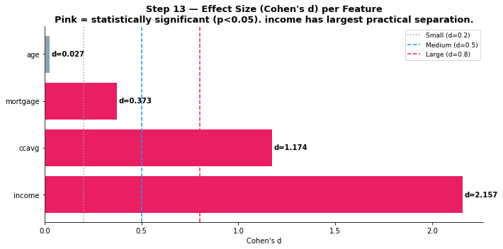

```python
test_cols = [c for c in ['age', 'income', 'ccavg', 'mortgage'] if c in df.columns]
results = []
for col in test_cols:
    g0 = df[df['personal_loan']==0][col].dropna()
    g1 = df[df['personal_loan']==1][col].dropna()
    _, p = mannwhitneyu(g0, g1, alternative='two-sided')
    d = (g1.mean() - g0.mean()) / (np.sqrt((g0.std()**2 + g1.std()**2) / 2) + 1e-9)
    results.append({'feature': col, 'mean_no_loan': round(g0.mean(),2), 'mean_loan': round(g1.mean(),2),
                    'p_value': round(p,6), 'significant': '✅ YES' if p<0.05 else '❌ NO',
                    'cohens_d': round(abs(d),3),
                    'effect_size': 'Large' if abs(d)>0.8 else 'Medium' if abs(d)>0.5 else 'Small'})

sig_df = pd.DataFrame(results).sort_values('cohens_d', ascending=False)
print('Statistical Significance + Effect Size:'); display(sig_df)

fig, ax = plt.subplots(figsize=(10, 5))
colors = [PINK if p < 0.05 else GRAY for p in sig_df['p_value']]
bars   = ax.barh(sig_df['feature'], sig_df['cohens_d'], color=colors, edgecolor='white')
ax.axvline(0.2, color=GRAY, linestyle=':', linewidth=1.5, label='Small (d=0.2)')
ax.axvline(0.5, color=BLUE, linestyle='--', linewidth=1.5, label='Medium (d=0.5)')
ax.axvline(0.8, color=PINK, linestyle='--', linewidth=1.5, label='Large (d=0.8)')
for bar, d in zip(bars, sig_df['cohens_d']):
    ax.text(d + 0.01, bar.get_y() + bar.get_height()/2, f'd={d:.3f}', va='center', fontsize=10, fontweight='bold')
ax.set_title("Step 13 — Effect Size (Cohen's d) per Feature\n"
             'Pink = statistically significant (p<0.05). income has largest practical separation.',
             fontweight='bold')
ax.set_xlabel("Cohen's d"); ax.legend(fontsize=9)
plt.tight_layout(); plt.show()
```

**💡 Business insight:** Effect size ranking predicts feature importance in trained model — income and ccavg should appear as top SHAP features.

## Step 14 — Feature Correlation with Target (Point-Biserial)

**Why:** Point-biserial correlation measures linear association between continuous feature and binary target. Positive = higher value → more likely to accept loan. Direction matters for business interpretation.

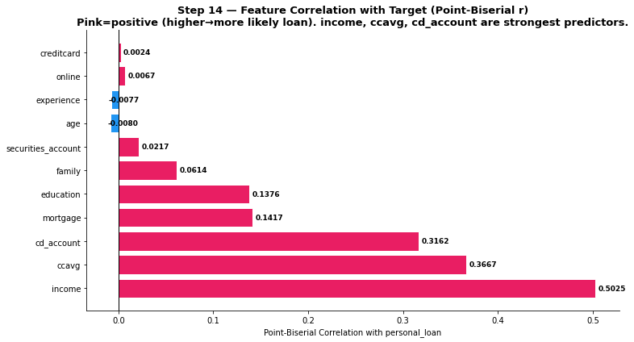

```
Top 8 correlations:
```

|  | feature | correlation | p_value | direction |
| --- | --- | --- | --- | --- |
| 2 | income | 0.5025 | 0.000000 | Positive ↑ |
| 4 | ccavg | 0.3667 | 0.000000 | Positive ↑ |
| 8 | cd_account | 0.3162 | 0.000000 | Positive ↑ |
| 6 | mortgage | 0.1417 | 0.000000 | Positive ↑ |
| 5 | education | 0.1376 | 0.000000 | Positive ↑ |
| 3 | family | 0.0614 | 0.000014 | Positive ↑ |
| 7 | securities_account | 0.0217 | 0.125989 | Positive ↑ |
| 0 | age | -0.0080 | 0.572041 | Negative ↓ |

```python
numeric_cols = [c for c in df.select_dtypes(include=np.number).columns if c != 'personal_loan']
corr_results = []
for col in numeric_cols:
    r, p = pointbiserialr(df['personal_loan'], df[col].fillna(df[col].median()))
    corr_results.append({'feature': col, 'correlation': round(r,4), 'p_value': round(p,6),
                         'direction': 'Positive ↑' if r > 0 else 'Negative ↓'})

corr_df = pd.DataFrame(corr_results).sort_values('correlation', key=abs, ascending=False)

fig, ax = plt.subplots(figsize=(11, 6))
colors = [PINK if r > 0 else BLUE for r in corr_df['correlation']]
bars   = ax.barh(corr_df['feature'], corr_df['correlation'], color=colors, edgecolor='white')
ax.axvline(0, color='black', linewidth=1)
for bar, r in zip(bars, corr_df['correlation']):
    offset = 0.003 if r > 0 else -0.003; ha = 'left' if r > 0 else 'right'
    ax.text(r + offset, bar.get_y() + bar.get_height()/2, f'{r:.4f}', va='center', fontsize=9, fontweight='bold')
ax.set_title('Step 14 — Feature Correlation with Target (Point-Biserial r)\n'
             'Pink=positive (higher→more likely loan). income, ccavg, cd_account are strongest predictors.',
             fontweight='bold')
ax.set_xlabel('Point-Biserial Correlation with personal_loan')
plt.tight_layout(); plt.show()
print('\nTop 8 correlations:'); display(corr_df.head(8))
```

**📌 Observation:** `income`, `ccavg`, `cd_account` are strongest positive predictors. `age` near-zero — confirms Step 10.

**💡 Pipeline decision:** SelectKBest with `mutual_info_classif` used — captures both linear and non-linear associations, more powerful than correlation for feature selection.

## Step 15 — Feature Correlation Matrix

**Why:** Inter-feature correlations reveal multicollinearity. Highly correlated features carry redundant information — hurts linear model interpretability without improving prediction.

**Business insight:** `income` and `ccavg` being correlated is expected — high earners spend more. But correlation is not perfect, so both carry independent signal.

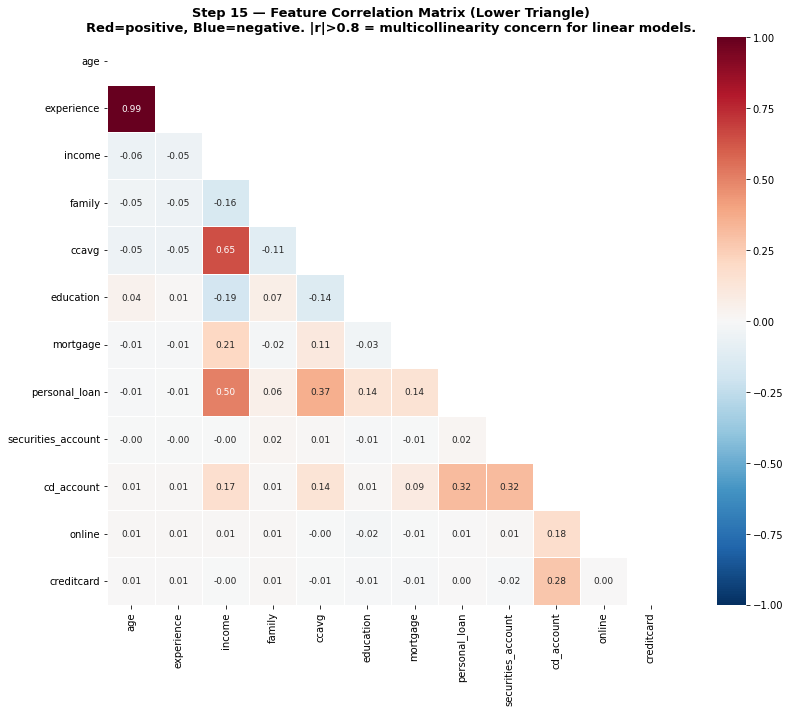

```
Feature pairs with |r| > 0.5:
```

|  | feature_1 | feature_2 | r |
| --- | --- | --- | --- |
| 0 | experience | age | 0.9942 |
| 1 | ccavg | income | 0.6461 |

```python
corr_matrix = df.select_dtypes(include=np.number).corr()
mask        = np.triu(np.ones_like(corr_matrix, dtype=bool))
fig, ax = plt.subplots(figsize=(13, 10))
sns.heatmap(corr_matrix, mask=mask, annot=True, fmt='.2f',
            cmap='RdBu_r', center=0, vmin=-1, vmax=1,
            linewidths=0.5, linecolor='white', annot_kws={'size': 9}, ax=ax, square=True)
ax.set_title('Step 15 — Feature Correlation Matrix (Lower Triangle)\n'
             'Red=positive, Blue=negative. |r|>0.8 = multicollinearity concern for linear models.',
             fontweight='bold')
plt.tight_layout(); plt.show()

high_corr = []
for i in range(len(corr_matrix.columns)):
    for j in range(i):
        r = corr_matrix.iloc[i, j]
        if abs(r) > 0.5 and corr_matrix.index[i] != 'personal_loan':
            high_corr.append({'feature_1': corr_matrix.index[i], 'feature_2': corr_matrix.columns[j], 'r': round(r,4)})
if high_corr:
    print('\nFeature pairs with |r| > 0.5:')
    display(pd.DataFrame(high_corr).sort_values('r', key=abs, ascending=False))
```

**💡 Pipeline decision:** `SelectKBest(k=10)` removes least informative features, naturally handling remaining inter-feature redundancy.